# External Cues and Policy Preferences: Rethinking the Drivers of Policy Positions

Date: 2024-04-20

# Open data

```r
data_long <- readRDS("data/derived-data/data_long.rds")

load("outputs/data/inter_power_1.RData")
load("outputs/data/inter_power_2.RData")
```

# Paper replication

### Figure 1 - Average treatment effect of policy cues

Replication of Figure 1 ATE Across Issues on Barber & Pope (2019) but without separating by party

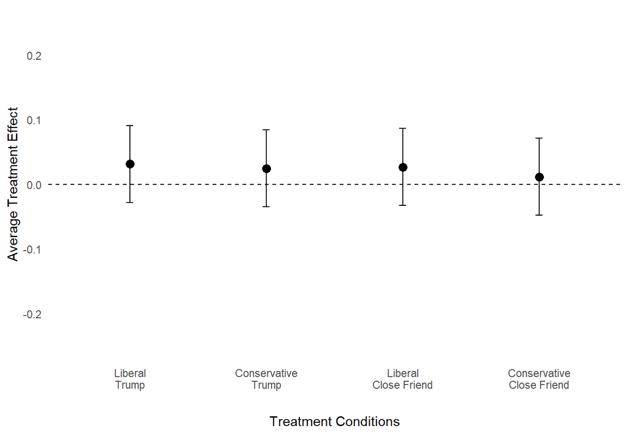

```r
model1 <- lm(policy_opinion ~ male + pid3 + treatment_group, data = data_long)

ate_m1 <- tidy(model1) %>%
  filter(term %in% c("treatment_groupTL", "treatment_groupTC",
                     "treatment_groupCFL", "treatment_groupCFC")) %>%
  mutate(term = case_when(
    term == "treatment_groupTL" ~ "Liberal Trump",
    term == "treatment_groupTC" ~ "Conservative Trump",
    term == "treatment_groupCFL" ~ "Liberal Close Friend",
    term == "treatment_groupCFC" ~ "Conservative Close Friend",
    TRUE ~ term))

ate_m1$term <- factor(ate_m1$term, levels = c("Liberal Trump",
                                              "Conservative Trump",
                                              "Liberal Close Friend",
                                              "Conservative Close Friend"))


# Calculate CI
ate_m1 <- ate_m1 %>%
  mutate(conf.low = estimate - 1.96 * std.error,
         conf.high = estimate + 1.96 * std.error)


# Plot
ate_plot <- ggplot(ate_m1, aes(x = term, y = estimate)) +
  geom_errorbar(aes(ymin = conf.low, ymax = conf.high),
                position = position_dodge(width = 0.7), width = 0.05) +
  geom_point(position = position_dodge(width = 0.7), size = 3) +
  geom_hline(yintercept = 0, linetype = "dashed", color = "black") +
  xlab("Treatment Conditions") +
  ylab("Average Treatment Effect") +
  scale_x_discrete(labels = c("Liberal\nTrump",
                              "Conservative\nTrump",
                              "Liberal\nClose Friend",
                              "Conservative\nClose Friend")) +
  scale_y_continuous(limits = c(-0.25, 0.25)) +
  theme_minimal() +
  theme(legend.position = "none",
        panel.grid.major = element_blank(),
        panel.grid.minor = element_blank(),
        panel.background = element_blank(),
        axis.title.x = element_text(margin = margin(t = 20, b = 10)))

ate_plot
```

### Figure 2 - Interaction with Party ID

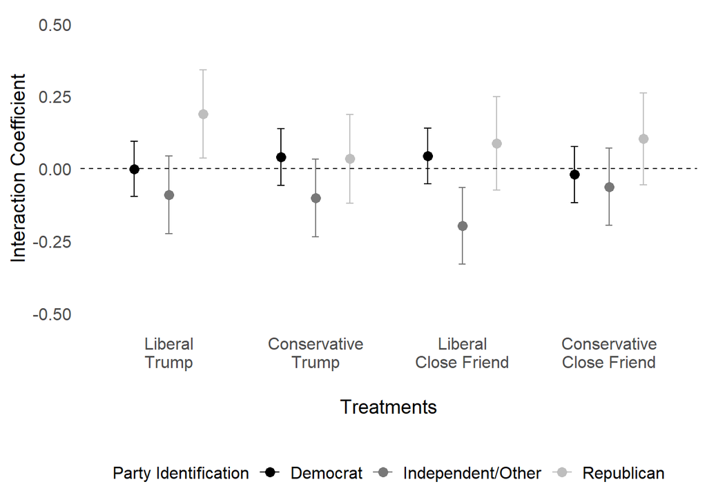

```r
model2 <- lm(policy_opinion ~ male + party_id + treatment_group*party_id, data = data_long)

# CIs
tidy_m2 <- tidy(model2) %>%
  mutate(conf.low = estimate - 1.96 * std.error,
         conf.high = estimate + 1.96 * std.error)

term_labels <- c(
  "treatment_groupTL" = "Democrat:Liberal Trump",
  "treatment_groupTC" = "Democrat:Conservative Trump",
  "treatment_groupCFL" = "Democrat:Liberal Close Friend",
  "treatment_groupCFC" = "Democrat:Conservative Close Friend",
  "party_idIndependent/Other:treatment_groupTL" = "Independent/Other:Liberal Trump",
  "party_idRepublican:treatment_groupTL" = "Republican:Liberal Trump",
  "party_idIndependent/Other:treatment_groupTC" = "Independent/Other:Conservative Trump",
  "party_idRepublican:treatment_groupTC" = "Republican:Conservative Trump",
  "party_idIndependent/Other:treatment_groupCFL" = "Independent/Other:Liberal Close Friend",
  "party_idRepublican:treatment_groupCFL" = "Republican:Liberal Close Friend",
  "party_idIndependent/Other:treatment_groupCFC" = "Independent/Other:Conservative Close Friend",
  "party_idRepublican:treatment_groupCFC" = "Republican:Conservative Close Friend")

# Relabel terms and combine main and interaction effects
ate_m2 <- tidy_m2 %>%
  mutate(term = if_else(term %in% names(term_labels), term_labels[term], term)) %>%
  filter(term != "(Intercept)")  # Exclude intercept from this dataframe

# Extract intercept (effect for Democrats)
intercept_m2 <- filter(tidy_m2, term == "(Intercept)")

# Add the intercept as the effect for Democrats
ate_m2 %<>%
  add_row(term = "Democrat:Baseline",
          estimate = intercept_m2$estimate,
          std.error = intercept_m2$std.error,
          conf.low = intercept_m2$estimate - 1.96 * intercept_m2$std.error,
          conf.high = intercept_m2$estimate + 1.96 * intercept_m2$std.error)

# Add column for treatment and party id to use them in the plot
ate_m2 %<>%
  mutate(
    treatment = case_when(
      str_detect(term, "Liberal Trump") ~ "Liberal Trump",
      str_detect(term, "Conservative Trump") ~ "Conservative Trump",
      str_detect(term, "Liberal Close Friend") ~ "Liberal Close Friend",
      str_detect(term, "Conservative Close Friend") ~ "Conservative Close Friend"),
    party_id = case_when(
      str_detect(term, "^Democrat:") ~ "Democrat",
      str_detect(term, "^Independent/Other:") ~ "Independent/Other",
      str_detect(term, "^Republican:") ~ "Republican")) %>%
  filter(!is.na(treatment))

# Plot
ate_plot2 <- ggplot(ate_m2, aes(x = term, y = estimate)) +
  geom_errorbar(aes(ymin = conf.low, ymax = conf.high),
                position = position_dodge(width = 0.7), width = 0.05) +
  geom_point(position = position_dodge(width = 0.7), size = 3) +
  geom_hline(yintercept = 0, linetype = "dashed", color = "black") +
  xlab("Treatment Conditions") +
  ylab("Average Treatment Effect") +
  scale_x_discrete(labels = c("Liberal\nTrump",
                              "Conservative\nTrump",
                              "Liberal\nClose Friend",
                              "Conservative\nClose Friend")) +
  scale_y_continuous(limits = c(-0.25, 0.25)) +
  theme_minimal() +
  theme(legend.position = "none",
        panel.grid.major = element_blank(),
        panel.grid.minor = element_blank(),
        panel.background = element_blank())

# Relevel
ate_m2$treatment <- factor(ate_m2$treatment, levels = c(
  "Liberal Trump",
  "Conservative Trump",
  "Liberal Close Friend",
  "Conservative Close Friend"))

ate_plot2 <- ggplot(ate_m2, aes(x = treatment, y = estimate, color = party_id)) +
  geom_errorbar(aes(ymin = conf.low, ymax = conf.high),
                position = position_dodge(width = 0.7), width = 0.15) +
  geom_point(position = position_dodge(width = 0.7), size = 3) +
  geom_hline(yintercept = 0, linetype = "dashed", color = "black") +
  labs(x = "Treatments", y = "Interaction Coefficient", color = "Party Identification") +
  scale_y_continuous(limits = c(-0.5, 0.5)) +
  theme_minimal(base_size = 14) +  #
  theme(legend.position = "bottom",
        legend.title = element_text(size = 12),
        legend.text = element_text(size = 12),
        panel.grid.major = element_blank(),
        panel.grid.minor = element_blank(),
        panel.background = element_blank(),
        axis.title.x = element_text(size = 14, margin = margin(t = 20, b = 10)),
        axis.title.y = element_text(size = 14),
        axis.text.x = element_text(size = 12),
        axis.text.y = element_text(size = 12)) +
  scale_color_manual(values = c("Democrat" = "black",
                                "Independent/Other" = "#787878",
                                "Republican" = "gray")) +
  scale_x_discrete(labels = c("Liberal\nTrump",
                              "Conservative\nTrump",
                              "Liberal\nClose Friend",
                              "Conservative\nClose Friend"))

ate_plot2
```

### Figure 3 - Interaction with Trump approval

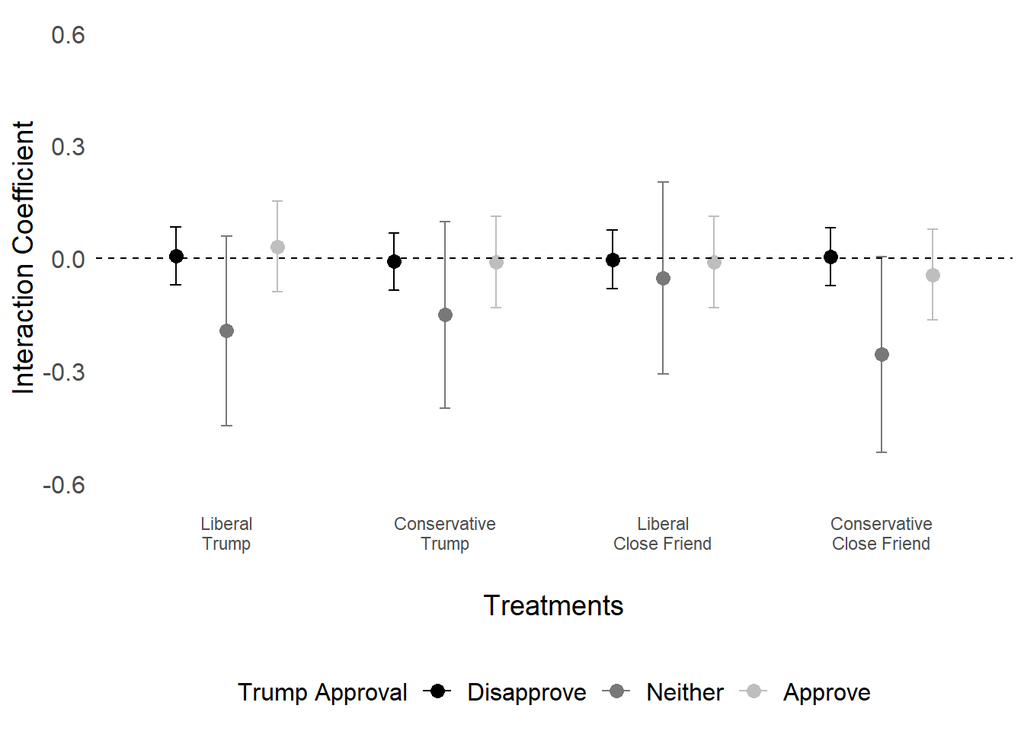

```r
# Factor interaction
model2_ta <- lm(policy_opinion ~ male + trump_approve +
                  treatment_group * trump_approve, data = data_long)


tidy_m2_ta <- tidy(model2_ta, conf.int = TRUE)

# Labels for trump_approve interaction terms
term_labels_ta <- c(
  "treatment_groupTL" = "Disapprove:Liberal Trump",
  "treatment_groupTC" = "Disapprove:Conservative Trump",
  "treatment_groupCFL" = "Disapprove:Liberal Close Friend",
  "treatment_groupCFC" = "Disapprove:Conservative Close Friend",
  "trump_approveNeither:treatment_groupTL" = "Neither:Liberal Trump",
  "trump_approveApprove:treatment_groupTL" = "Approve:Liberal Trump",
  "trump_approveNeither:treatment_groupTC" = "Neither:Conservative Trump",
  "trump_approveApprove:treatment_groupTC" = "Approve:Conservative Trump",
  "trump_approveNeither:treatment_groupCFL" = "Neither:Liberal Close Friend",
  "trump_approveApprove:treatment_groupCFL" = "Approve:Liberal Close Friend",
  "trump_approveNeither:treatment_groupCFC" = "Neither:Conservative Close Friend",
  "trump_approveApprove:treatment_groupCFC" = "Approve:Conservative Close Friend")


# Relabel terms for trump_approve
ate_m2_ta <- tidy_m2_ta %>%
  mutate(term = if_else(term %in% names(term_labels_ta), term_labels_ta[term], term)) %>%
  filter(term != "(Intercept)")  # Exclude intercept

# Extract and handle intercept (effect for Disapprove as baseline)
intercept_m2_ta <- filter(tidy_m2_ta, term == "(Intercept)")

ate_m2_ta %<>%
  add_row(term = "Disapprove:Baseline",
          estimate = intercept_m2_ta$estimate,
          std.error = intercept_m2_ta$std.error,
          conf.low = intercept_m2_ta$estimate - 1.96 * intercept_m2_ta$std.error,
          conf.high = intercept_m2_ta$estimate + 1.96 * intercept_m2_ta$std.error)

# Add column for treatment and trump_approve to use in the plot
ate_m2_ta %<>%
  mutate(
    treatment = case_when(
      str_detect(term, "Liberal Trump") ~ "Liberal Trump",
      str_detect(term, "Conservative Trump") ~ "Conservative Trump",
      str_detect(term, "Liberal Close Friend") ~ "Liberal Close Friend",
      str_detect(term, "Conservative Close Friend") ~ "Conservative Close Friend",
      TRUE ~ as.character(term)  # To handle the Disapprove:Baseline
    ),
    trump_approve = case_when(
      str_detect(term, "^Disapprove:") ~ "Disapprove",
      str_detect(term, "^Neither:") ~ "Neither",
      str_detect(term, "^Approve:") ~ "Approve")) %>%
  filter(!is.na(trump_approve))


ate_m2_ta$treatment <- factor(ate_m2_ta$treatment, levels = c(
  "Liberal Trump",
  "Conservative Trump",
  "Liberal Close Friend",
  "Conservative Close Friend"))

ate_m2_ta %<>%
  filter(!is.na(treatment))

# Reorder levels of trump_approve
ate_m2_ta$trump_approve <- factor(ate_m2_ta$trump_approve, levels = c("Disapprove", "Neither", "Approve"))


# Plot
ate_plot2_ta <- ggplot(ate_m2_ta, aes(x = treatment, y = estimate, color = trump_approve)) +
  geom_errorbar(aes(ymin = conf.low, ymax = conf.high),
                position = position_dodge(width = 0.7), width = 0.15) +
  geom_point(position = position_dodge(width = 0.7), size = 3) +
  geom_hline(yintercept = 0, linetype = "dashed", color = "black") +
  labs(x = "Treatments", y = "Interaction Coefficient", color = "Trump Approval") +
  scale_color_manual(values = c("Disapprove" = "black",
                                "Neither" = "#787878",
                                "Approve" = "gray")) +
  theme_minimal() +
  theme(
    axis.title.x = element_text(size = 14, margin = margin(t = 20, b = 10)),
    axis.title.y = element_text(size = 14),
    axis.text.y = element_text(size = 12),
    legend.position = "bottom",
    legend.title = element_text(size = 12),
    legend.text = element_text(size = 12),
    panel.grid.major = element_blank(),
    panel.grid.minor = element_blank(),
    panel.background = element_blank()
  ) +
  scale_x_discrete(labels = c("Liberal\nTrump",
                              "Conservative\nTrump",
                              "Liberal\nClose Friend",
                              "Conservative\nClose Friend")) +
  scale_y_continuous(limits = c(-0.6, 0.6))

ate_plot2_ta
```

### Figure 4 - Interaction with political knowledge

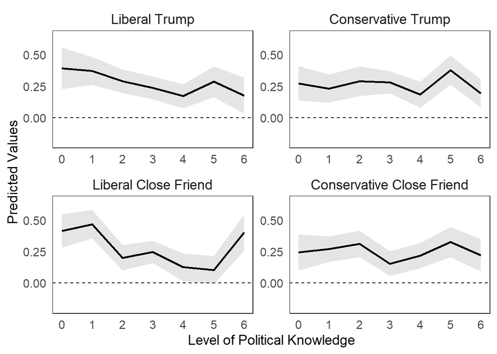

```r
model3 <- lm(policy_opinion ~ male + pid3 + factor(knowledge) +
               treatment_group*factor(knowledge), data = data_long)

model3b <- lm(policy_opinion ~ male + pid3 + knowledge +
               treatment_group*knowledge, data = data_long)

m3_TL <- ggpredict(model3, terms = c("knowledge", "treatment_group[TL]"))
m3_TC <- ggpredict(model3, terms = c("knowledge", "treatment_group[TC]"))
m3_CFL <- ggpredict(model3, terms = c("knowledge", "treatment_group[CFL]"))
m3_CFC <- ggpredict(model3, terms = c("knowledge", "treatment_group[CFC]"))

model3_table <- rbind(transform(m3_TL, treatment = "TL"),
                      transform(m3_TC, treatment = "TC"),
                      transform(m3_CFL, treatment = "CFL"),
                      transform(m3_CFC, treatment = "CFC"))

model3_table$treatment <- factor(model3_table$treatment,
                                 levels = c("TL", "TC", "CFL", "CFC"),
                                 labels = c("Liberal Trump", "Conservative Trump",
                                            "Liberal Close Friend",
                                            "Conservative Close Friend"))

model3_plot <- ggplot(model3_table, aes(x = x, y = predicted, group = treatment)) +
  geom_ribbon(aes(ymin = conf.low, ymax = conf.high, group = treatment),
              fill = "grey80", alpha = 0.5) +  # Confidence intervals
  geom_line(color = "black", linewidth = 1) +
  geom_hline(yintercept = 0, linetype = "dashed", color = "black") +
  facet_wrap(~treatment, scales = "free", ncol = 2) +
  labs(y = "Predicted Values", x = "Level of Political Knowledge") +
  theme_minimal(base_size = 14) +
  theme(legend.position = "none",
        strip.background = element_blank(),
        strip.text.x = element_text(size = 14),
        panel.grid.major = element_blank(),
        panel.grid.minor = element_blank(),
        panel.background = element_blank(),
        panel.border = element_rect(linetype = "solid",
                                    fill = NA, color = "black", linewidth = 0.5),
        axis.title.x = element_text(size = 14),
        axis.title.y = element_text(size = 14),
        axis.text.x = element_text(size = 12),
        axis.text.y = element_text(size = 12)) +
  coord_cartesian(ylim = c(-0.2, 0.65)) +
  scale_x_continuous(breaks = 0:6)


model3_plot
```

### Figure 5 - Interaction with social conformism

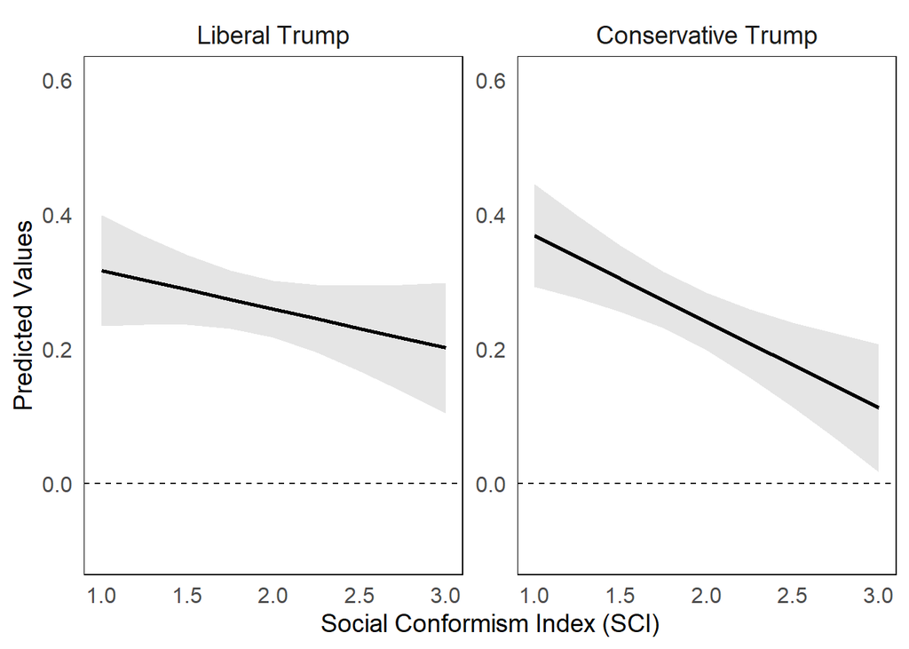

```r
model_4 <- lm(policy_opinion ~ male + pid3 + treatment_group*SCI, data = data_long)

m4_TL <- ggpredict(model_4, terms = c("SCI", "treatment_group[TL]"))
m4_TC <- ggpredict(model_4, terms = c("SCI", "treatment_group[TC]"))
m4_CFL <- ggpredict(model_4, terms = c("SCI", "treatment_group[CFL]"))
m4_CFC <- ggpredict(model_4, terms = c("SCI", "treatment_group[CFC]"))

model4_table <- rbind(transform(m4_TL, treatment = "TL"),
                      transform(m4_TC, treatment = "TC"),
                      transform(m4_CFL, treatment = "CFL"),
                      transform(m4_CFC, treatment = "CFC"))

model4_table$treatment <- factor(model4_table$treatment,
                                 levels = c("TL", "TC", "CFL", "CFC"),
                                 labels = c("Liberal Trump", "Conservative Trump",
                                            "Liberal Close Friend",
                                            "Conservative Close Friend"))

# Subset the data for Trump
m4_trump_effects <- subset(model4_table, treatment %in% c("Liberal Trump", "Conservative Trump"))

# Subset the data for Close Friend
m4_cf_effects <- subset(model4_table, treatment %in% c("Liberal Close Friend", "Conservative Close Friend"))

# Plot for Trump treatments
m4_plot_trump <- ggplot(m4_trump_effects, aes(x = x, y = predicted, group = treatment)) +
  geom_ribbon(aes(ymin = conf.low, ymax = conf.high, fill = treatment), fill = "grey80", alpha = 0.5) +  # Confidence intervals
  geom_line(color = "black", size = 1) +
  geom_hline(yintercept = 0, linetype = "dashed", color = "black") +
  facet_wrap(~treatment, scales = "free", ncol = 2) +
  labs(y = "Predicted Values", x = "Social Conformism Index (SCI)") +
  scale_x_continuous(breaks = 0:6) +
  theme_minimal(base_size = 14) +
  theme(legend.position = "none",
        strip.background = element_blank(),
        strip.text.x = element_text(size = 14),
        panel.grid.major = element_blank(),
        panel.grid.minor = element_blank(),
        panel.background = element_blank(),
        panel.border = element_rect(linetype = "solid",
                                    fill = NA, color = "black", size = 0.5),
        axis.title.x = element_text(size = 14),
        axis.title.y = element_text(size = 14),
        axis.text.x = element_text(size = 12),
        axis.text.y = element_text(size = 12)) +
  scale_x_continuous(breaks = seq(1, 3, by = 0.5)) +
  coord_cartesian(ylim = c(-0.1, 0.6))
m4_plot_trump
```

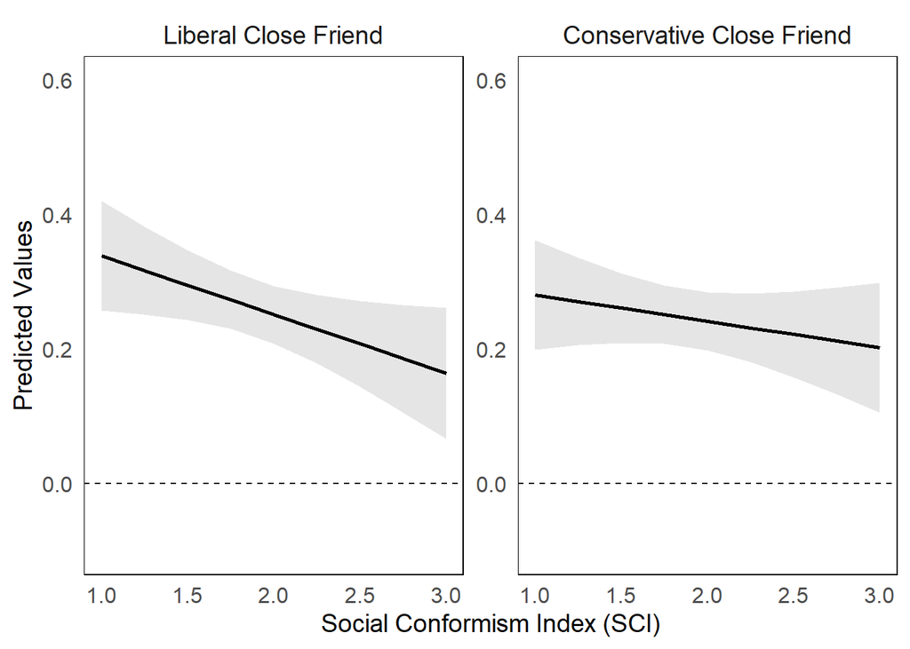

```r
# Plot for Close Friend treatments
m4_plot_cf <- ggplot(m4_cf_effects, aes(x = x, y = predicted, group = treatment)) +
  geom_ribbon(aes(ymin = conf.low, ymax = conf.high, fill = treatment), fill = "grey80", alpha = 0.5) +
  geom_line(aes(color = treatment), size = 1, color = "black") +
  geom_hline(yintercept = 0, linetype = "dashed", color = "black") +
  facet_wrap(~treatment, scales = "free", ncol = 2) +
  labs(y = "Predicted Values", x = "Social Conformism Index (SCI)") +
  theme_minimal(base_size = 14) +
  theme(legend.position = "none",
        strip.background = element_blank(),
        strip.text.x = element_text(size = 14),
        panel.grid.major = element_blank(),
        panel.grid.minor = element_blank(),
        panel.background = element_blank(),
        panel.border = element_rect(linetype = "solid",
                                    fill = NA, color = "black", size = 0.5),
        axis.title.x = element_text(size = 14),
        axis.title.y = element_text(size = 14),
        axis.text.x = element_text(size = 12),
        axis.text.y = element_text(size = 12)) +
  scale_x_continuous(breaks = seq(1, 3, by = 0.5)) +
  coord_cartesian(ylim = c(-0.1, 0.6))

m4_plot_cf
```

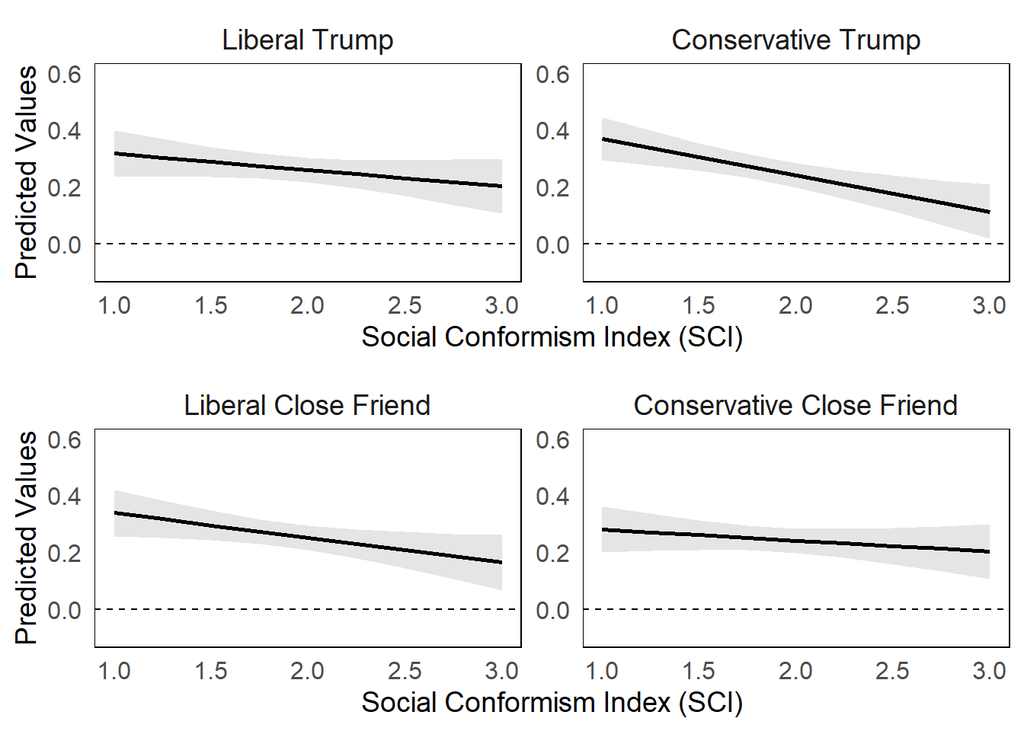

```r
m4_plot_final <- grid.arrange(m4_plot_trump, m4_plot_cf, nrow = 2)
```

# Supplementary Information Replication

## Power Analysis

```r
# Parameters
effect_size_f <- 0.11    # according to PAP
k <- 5                   # Number of groups
n_per_group <- 1000 / k  # Sample size per group
alpha <- 0.05            # Significance level
power <- 0.80            # Desired power

# Minimum effect size
min_effect_size <- pwr.anova.test(k = k, n = n_per_group, sig.level = alpha, power = power, f = NULL)

# Without the sample size, to get the required sample size per group
min_sample_size_group <- pwr.anova.test(k = k, n = NULL, f = effect_size_f, sig.level = alpha, power = power)

# 3) Outputs

# Convert the results to data frames for xtable
df_min_effect_size <- as.data.frame(t(as.matrix(unlist(min_effect_size))))

df_min_effect_size
```

```
##   k   n                 f sig.level power                      note
## 1 5 200 0.109512602332041      0.05   0.8 n is number in each group
##                                                    method
## 1 Balanced one-way analysis of variance power calculation
```

```r
df_min_sample_size_group <- as.data.frame(t(as.matrix(unlist(min_sample_size_group))))

df_min_sample_size_group
```

```
##   k                n    f sig.level power                      note
## 1 5 198.228518688395 0.11      0.05   0.8 n is number in each group
##                                                    method
## 1 Balanced one-way analysis of variance power calculation
```

### Power of Interactions

Get correlations between variables: First necessary correlation: Correlation between Y (policy opinion) and X1 (treatment) assumed to be close to zero as treatment is randomized. It’ll be zero for all the interactions

```r
xy_cor <- 0.00
```

Second necessary correlation: between the interacting variable X2 and Y (policy opinion) Different scenarios: (1) X2 = party ID: lower value (democrat) assumed to be correlated to higher values of policy positions (liberal position), therefore, negative correlation. (2) X2 = Trump approval: lower value (disapproves) assumed to be correlated to higher values of policy positions (liberal position), therefore, negative correlation. (3) X2 = Political knowledge: higher values (more knowledge) assumed to be correlated to higher values of policy positions (liberal position), therefore, positive correlation. (4) X2 = Social conformism: higher values (more conformism) assumed to be correlated to lower values of policy positions (conservative position), therefore, negative correlation.

```r
x2y_cor <- -0.05

x2y_cor2 <- 0.05 # only for political knowledge interaction
```

Third necessary correlation: between X1 (treatment) and interacting variable. is assumed at zero since the treatment is random

```r
x1x2_cor <- 0.00
```

Finally, the interaction effect between X1 X2 and Y is assumed to be amplified when compared to x2y_cor and x2y_cor2, therefore:

```r
x1x2y_cor <- -0.10

x1x2y_cor2 <- 0.10  # only for political knowledge interaction
```

First, using variable correlations, we conduct an overall power for each group sample of n = 200

```r
power_group <- power_interaction_r2(
  alpha = 0.05,             # alpha, for the power analysis
  N = 200,                  # sample size
  r.x1x2.y = .20,           # interaction effect to test (correlation between x1*x2 and y)
  r.x1.y = .0,              # correlation between x1 and y
  r.x2.y = .15,              # correlation between x2 and y
  r.x1.x2 = .0)              # correlation between x1 and x2

power_group
```

```
##         pwr
## 1 0.8065983
```

Calculation of power for interactions (1), (2) and (4)

```r
inter_power_1 <- power_interaction(
  n.iter = 10000,           # number of simulations per unique combination of input parameters
  alpha = 0.05,             # alpha, for the power analysis
  N = 1000,                 # sample size
  r.x1x2.y = x1x2y_cor,     # interaction effect to test (correlation between x1*x2 and y)
  r.x1.y = xy_cor,          # correlation between x1 and y
  r.x2.y = x2y_cor,         # correlation between x2 and y
  r.x1.x2 = x1x2_cor,       # correlation between x1 and x2
  k.y =  3,                 # categories `policy_opinion`
  k.x1 = 5)                 # 5 treatment groups (4 treatment + 1 control)
```

```r
inter_power_1
```

```
##      N    pwr
## 1 1000 0.8799
```

```r
inter_power_2 <- power_interaction(
  n.iter = 10000,           # number of simulations per unique combination of input parameters
  alpha = 0.05,             # alpha, for the power analysis
  N = 1000,                 # sample size
  r.x1x2.y = x1x2y_cor2,     # interaction effect to test (correlation between x1*x2 and y)
  r.x1.y = xy_cor,          # correlation between x1 and y
  r.x2.y = x2y_cor2,         # correlation between x2 and y
  r.x1.x2 = x1x2_cor,       # correlation between x1 and x2
  k.y =  3,                 # categories `policy_opinion`
  k.x1 = 5)                 # 5 treatment groups (4 treatment + 1 control)
```

```r
inter_power_2
```

```
##      N    pwr
## 1 1000 0.8869
```

### Table B1.1 - Mean Demographic Values by Treatment Group

```r
data_balance <- data_long[data_long$policy_issue == "1",]
table(data_balance$treatment_group)
```

```
##
## control      TL      TC     CFL     CFC
##     194     202     206     200     198
```

```r
by(data_balance$age, data_balance$treatment_group, mean)
```

```
## data_balance$treatment_group: control
## [1] 51.14433
## ------------------------------------------------------------
## data_balance$treatment_group: TL
## [1] 49.85644
## ------------------------------------------------------------
## data_balance$treatment_group: TC
## [1] 49.1699
## ------------------------------------------------------------
## data_balance$treatment_group: CFL
## [1] 47.865
## ------------------------------------------------------------
## data_balance$treatment_group: CFC
## [1] 49.96465
```

```r
summary(model1 <- lm(age ~ libtrump + contrump + libfriend + confriend, data = data_balance))
```

```
##
## Call:
## lm(formula = age ~ libtrump + contrump + libfriend + confriend,
##     data = data_balance)
##
## Residuals:
##     Min      1Q  Median      3Q     Max
## -33.144 -14.965   1.139  13.830  44.144
##
## Coefficients:
##             Estimate Std. Error t value            Pr(>|t|)
## (Intercept)   51.144      1.253  40.826 <0.0000000000000002 ***
## libtrump      -1.288      1.754  -0.734              0.4630
## contrump      -1.974      1.746  -1.131              0.2583
## libfriend     -3.279      1.758  -1.865              0.0625 .
## confriend     -1.180      1.763  -0.669              0.5035
## ---
## Signif. codes:  0 '***' 0.001 '**' 0.01 '*' 0.05 '.' 0.1 ' ' 1
##
## Residual standard error: 17.45 on 995 degrees of freedom
## Multiple R-squared:  0.003757,   Adjusted R-squared:  -0.0002484
## F-statistic: 0.938 on 4 and 995 DF,  p-value: 0.4411
```

```r
by(data_balance$race_white, data_balance$treatment_group, mean)
```

```
## data_balance$treatment_group: control
## [1] 0.6443299
## ------------------------------------------------------------
## data_balance$treatment_group: TL
## [1] 0.6336634
## ------------------------------------------------------------
## data_balance$treatment_group: TC
## [1] 0.631068
## ------------------------------------------------------------
## data_balance$treatment_group: CFL
## [1] 0.66
## ------------------------------------------------------------
## data_balance$treatment_group: CFC
## [1] 0.6767677
```

```r
summary(model1 <- lm(race_white ~  libtrump + contrump + libfriend + confriend, data = data_balance))
```

```
##
## Call:
## lm(formula = race_white ~ libtrump + contrump + libfriend + confriend,
##     data = data_balance)
##
## Residuals:
##     Min      1Q  Median      3Q     Max
## -0.6768 -0.6337  0.3400  0.3663  0.3689
##
## Coefficients:
##             Estimate Std. Error t value            Pr(>|t|)
## (Intercept)  0.64433    0.03433  18.768 <0.0000000000000002 ***
## libtrump    -0.01067    0.04807  -0.222               0.824
## contrump    -0.01326    0.04784  -0.277               0.782
## libfriend    0.01567    0.04819   0.325               0.745
## confriend    0.03244    0.04831   0.672               0.502
## ---
## Signif. codes:  0 '***' 0.001 '**' 0.01 '*' 0.05 '.' 0.1 ' ' 1
##
## Residual standard error: 0.4782 on 995 degrees of freedom
## Multiple R-squared:  0.001294,   Adjusted R-squared:  -0.002721
## F-statistic: 0.3224 on 4 and 995 DF,  p-value: 0.8631
```

```r
by(data_balance$male, data_balance$treatment_group, mean)
```

```
## data_balance$treatment_group: control
## [1] 0.3247423
## ------------------------------------------------------------
## data_balance$treatment_group: TL
## [1] 0.4257426
## ------------------------------------------------------------
## data_balance$treatment_group: TC
## [1] 0.4223301
## ------------------------------------------------------------
## data_balance$treatment_group: CFL
## [1] 0.4
## ------------------------------------------------------------
## data_balance$treatment_group: CFC
## [1] 0.4141414
```

```r
summary(model1 <- lm(male ~  libtrump + contrump + libfriend + confriend, data = data_balance)) # significant
```

```
##
## Call:
## lm(formula = male ~ libtrump + contrump + libfriend + confriend,
##     data = data_balance)
##
## Residuals:
##     Min      1Q  Median      3Q     Max
## -0.4257 -0.4141 -0.3247  0.5777  0.6753
##
## Coefficients:
##             Estimate Std. Error t value            Pr(>|t|)
## (Intercept)  0.32474    0.03513   9.244 <0.0000000000000002 ***
## libtrump     0.10100    0.04919   2.053              0.0403 *
## contrump     0.09759    0.04895   1.994              0.0465 *
## libfriend    0.07526    0.04931   1.526              0.1273
## confriend    0.08940    0.04943   1.809              0.0708 .
## ---
## Signif. codes:  0 '***' 0.001 '**' 0.01 '*' 0.05 '.' 0.1 ' ' 1
##
## Residual standard error: 0.4893 on 995 degrees of freedom
## Multiple R-squared:  0.005722,   Adjusted R-squared:  0.001725
## F-statistic: 1.432 on 4 and 995 DF,  p-value: 0.2214
```

```r
by(data_balance$knowledge, data_balance$treatment_group, mean)
```

```
## data_balance$treatment_group: control
## [1] 2.819588
## ------------------------------------------------------------
## data_balance$treatment_group: TL
## [1] 3.009901
## ------------------------------------------------------------
## data_balance$treatment_group: TC
## [1] 3.160194
## ------------------------------------------------------------
## data_balance$treatment_group: CFL
## [1] 2.94
## ------------------------------------------------------------
## data_balance$treatment_group: CFC
## [1] 2.979798
```

```r
summary(model1 <- lm(knowledge ~  libtrump + contrump + libfriend + confriend, data = data_balance))
```

```
##
## Call:
## lm(formula = knowledge ~ libtrump + contrump + libfriend + confriend,
##     data = data_balance)
##
## Residuals:
##     Min      1Q  Median      3Q     Max
## -3.1602 -1.1602  0.0202  1.1804  3.1804
##
## Coefficients:
##             Estimate Std. Error t value            Pr(>|t|)
## (Intercept)   2.8196     0.1268  22.244 <0.0000000000000002 ***
## libtrump      0.1903     0.1775   1.072              0.2838
## contrump      0.3406     0.1766   1.928              0.0541 .
## libfriend     0.1204     0.1779   0.677              0.4987
## confriend     0.1602     0.1784   0.898              0.3693
## ---
## Signif. codes:  0 '***' 0.001 '**' 0.01 '*' 0.05 '.' 0.1 ' ' 1
##
## Residual standard error: 1.766 on 995 degrees of freedom
## Multiple R-squared:  0.003907,   Adjusted R-squared:  -9.738e-05
## F-statistic: 0.9757 on 4 and 995 DF,  p-value: 0.4198
```

```r
by(data_balance$trump_approve_num, data_balance$treatment_group, mean, na.rm = T)
```

```
## data_balance$treatment_group: control
## [1] 1.865979
## ------------------------------------------------------------
## data_balance$treatment_group: TL
## [1] 1.777228
## ------------------------------------------------------------
## data_balance$treatment_group: TC
## [1] 1.752427
## ------------------------------------------------------------
## data_balance$treatment_group: CFL
## [1] 1.795
## ------------------------------------------------------------
## data_balance$treatment_group: CFC
## [1] 1.762626
```

```r
summary(model1 <- lm(trump_approve_num ~ libtrump + contrump + libfriend + confriend, data = data_balance))
```

```
##
## Call:
## lm(formula = trump_approve_num ~ libtrump + contrump + libfriend +
##     confriend, data = data_balance)
##
## Residuals:
##     Min      1Q  Median      3Q     Max
## -0.8660 -0.7772 -0.7524  1.2050  1.2476
##
## Coefficients:
##             Estimate Std. Error t value            Pr(>|t|)
## (Intercept)  1.86598    0.06730  27.726 <0.0000000000000002 ***
## libtrump    -0.08875    0.09423  -0.942               0.346
## contrump    -0.11355    0.09378  -1.211               0.226
## libfriend   -0.07098    0.09446  -0.751               0.453
## confriend   -0.10335    0.09470  -1.091               0.275
## ---
## Signif. codes:  0 '***' 0.001 '**' 0.01 '*' 0.05 '.' 0.1 ' ' 1
##
## Residual standard error: 0.9374 on 995 degrees of freedom
## Multiple R-squared:  0.001823,   Adjusted R-squared:  -0.002189
## F-statistic: 0.4544 on 4 and 995 DF,  p-value: 0.7692
```

```r
by(data_balance$ideo5, data_balance$treatment_group, function(x) mean(x, na.rm = T))
```

```
## data_balance$treatment_group: control
## [1] 2.960452
## ------------------------------------------------------------
## data_balance$treatment_group: TL
## [1] 2.892473
## ------------------------------------------------------------
## data_balance$treatment_group: TC
## [1] 2.893617
## ------------------------------------------------------------
## data_balance$treatment_group: CFL
## [1] 2.955556
## ------------------------------------------------------------
## data_balance$treatment_group: CFC
## [1] 2.767956
```

```r
summary(model1 <- lm(ideo5 ~  libtrump + contrump + libfriend + confriend, data = data_balance))
```

```
##
## Call:
## lm(formula = ideo5 ~ libtrump + contrump + libfriend + confriend,
##     data = data_balance)
##
## Residuals:
##      Min       1Q   Median       3Q      Max
## -1.96045 -0.89362  0.04444  1.04444  2.23204
##
## Coefficients:
##              Estimate Std. Error t value            Pr(>|t|)
## (Intercept)  2.960452   0.091509  32.351 <0.0000000000000002 ***
## libtrump    -0.067979   0.127839  -0.532               0.595
## contrump    -0.066835   0.127507  -0.524               0.600
## libfriend   -0.004896   0.128873  -0.038               0.970
## confriend   -0.192496   0.128697  -1.496               0.135
## ---
## Signif. codes:  0 '***' 0.001 '**' 0.01 '*' 0.05 '.' 0.1 ' ' 1
##
## Residual standard error: 1.217 on 907 degrees of freedom
##   (88 observations deleted due to missingness)
## Multiple R-squared:  0.003218,   Adjusted R-squared:  -0.001178
## F-statistic: 0.732 on 4 and 907 DF,  p-value: 0.5702
```

```r
by(data_balance$pid7, data_balance$treatment_group, function(x) mean(x, na.rm = T))
```

```
## data_balance$treatment_group: control
## [1] 3.73822
## ------------------------------------------------------------
## data_balance$treatment_group: TL
## [1] 3.409091
## ------------------------------------------------------------
## data_balance$treatment_group: TC
## [1] 3.527919
## ------------------------------------------------------------
## data_balance$treatment_group: CFL
## [1] 3.364583
## ------------------------------------------------------------
## data_balance$treatment_group: CFC
## [1] 3.373684
```

```r
summary(model1 <- lm(pid7 ~  libtrump + contrump + libfriend + confriend, data = data_balance))
```

```
##
## Call:
## lm(formula = pid7 ~ libtrump + contrump + libfriend + confriend,
##     data = data_balance)
##
## Residuals:
##     Min      1Q  Median      3Q     Max
## -2.7382 -2.3646 -0.3691  1.6263  3.6354
##
## Coefficients:
##             Estimate Std. Error t value            Pr(>|t|)
## (Intercept)   3.7382     0.1537  24.317 <0.0000000000000002 ***
## libtrump     -0.3291     0.2155  -1.527              0.1270
## contrump     -0.2103     0.2157  -0.975              0.3299
## libfriend    -0.3736     0.2171  -1.721              0.0856 .
## confriend    -0.3645     0.2177  -1.675              0.0943 .
## ---
## Signif. codes:  0 '***' 0.001 '**' 0.01 '*' 0.05 '.' 0.1 ' ' 1
##
## Residual standard error: 2.125 on 963 degrees of freedom
##   (32 observations deleted due to missingness)
## Multiple R-squared:  0.004325,   Adjusted R-squared:  0.0001895
## F-statistic: 1.046 on 4 and 963 DF,  p-value: 0.3824
```

```r
by(data_balance$faminc_new, data_balance$treatment_group, function(x) mean(x, na.rm = T))
```

```
## data_balance$treatment_group: control
## [1] 6.344828
## ------------------------------------------------------------
## data_balance$treatment_group: TL
## [1] 6.141304
## ------------------------------------------------------------
## data_balance$treatment_group: TC
## [1] 6.165746
## ------------------------------------------------------------
## data_balance$treatment_group: CFL
## [1] 5.967914
## ------------------------------------------------------------
## data_balance$treatment_group: CFC
## [1] 6.05
```

```r
summary(model1 <- lm(faminc_new ~  libtrump + contrump + libfriend + confriend, data = data_balance))
```

```
##
## Call:
## lm(formula = faminc_new ~ libtrump + contrump + libfriend + confriend,
##     data = data_balance)
##
## Residuals:
##     Min      1Q  Median      3Q     Max
## -5.3448 -3.0500 -0.1657  2.8343 10.0321
##
## Coefficients:
##             Estimate Std. Error t value            Pr(>|t|)
## (Intercept)   6.3448     0.2645  23.987 <0.0000000000000002 ***
## libtrump     -0.2035     0.3690  -0.552               0.581
## contrump     -0.1791     0.3704  -0.483               0.629
## libfriend    -0.3769     0.3675  -1.026               0.305
## confriend    -0.2948     0.3709  -0.795               0.427
## ---
## Signif. codes:  0 '***' 0.001 '**' 0.01 '*' 0.05 '.' 0.1 ' ' 1
##
## Residual standard error: 3.489 on 901 degrees of freedom
##   (94 observations deleted due to missingness)
## Multiple R-squared:  0.001306,   Adjusted R-squared:  -0.003127
## F-statistic: 0.2946 on 4 and 901 DF,  p-value: 0.8815
```

```r
by(data_balance$educ, data_balance$treatment_group, function(x) mean(x, na.rm = T))
```

```
## data_balance$treatment_group: control
## [1] 3.659794
## ------------------------------------------------------------
## data_balance$treatment_group: TL
## [1] 3.594059
## ------------------------------------------------------------
## data_balance$treatment_group: TC
## [1] 3.791262
## ------------------------------------------------------------
## data_balance$treatment_group: CFL
## [1] 3.48
## ------------------------------------------------------------
## data_balance$treatment_group: CFC
## [1] 3.606061
```

```r
summary(model1 <- lm(educ ~  libtrump + contrump + libfriend + confriend, data = data_balance))
```

```
##
## Call:
## lm(formula = educ ~ libtrump + contrump + libfriend + confriend,
##     data = data_balance)
##
## Residuals:
##    Min     1Q Median     3Q    Max
## -2.791 -1.480 -0.480  1.394  2.520
##
## Coefficients:
##             Estimate Std. Error t value            Pr(>|t|)
## (Intercept)  3.65979    0.10679  34.270 <0.0000000000000002 ***
## libtrump    -0.06573    0.14953  -0.440               0.660
## contrump     0.13147    0.14881   0.883               0.377
## libfriend   -0.17979    0.14989  -1.199               0.231
## confriend   -0.05373    0.15026  -0.358               0.721
## ---
## Signif. codes:  0 '***' 0.001 '**' 0.01 '*' 0.05 '.' 0.1 ' ' 1
##
## Residual standard error: 1.487 on 995 degrees of freedom
## Multiple R-squared:  0.0047, Adjusted R-squared:  0.0006983
## F-statistic: 1.175 on 4 and 995 DF,  p-value: 0.3204
```

```r
by(data_balance$newsint, data_balance$treatment_group, function(x) mean(x, na.rm = T))
```

```
## data_balance$treatment_group: control
## [1] 1.882979
## ------------------------------------------------------------
## data_balance$treatment_group: TL
## [1] 1.734694
## ------------------------------------------------------------
## data_balance$treatment_group: TC
## [1] 1.808081
## ------------------------------------------------------------
## data_balance$treatment_group: CFL
## [1] 1.772487
## ------------------------------------------------------------
## data_balance$treatment_group: CFC
## [1] 1.803191
```

```r
summary(model1 <- lm(newsint ~  libtrump + contrump + libfriend + confriend, data = data_balance))
```

```
##
## Call:
## lm(formula = newsint ~ libtrump + contrump + libfriend + confriend,
##     data = data_balance)
##
## Residuals:
##     Min      1Q  Median      3Q     Max
## -0.8830 -0.8032  0.1170  0.2653  2.2653
##
## Coefficients:
##             Estimate Std. Error t value            Pr(>|t|)
## (Intercept)  1.88298    0.06938  27.141 <0.0000000000000002 ***
## libtrump    -0.14828    0.09711  -1.527               0.127
## contrump    -0.07490    0.09687  -0.773               0.440
## libfriend   -0.11049    0.09799  -1.128               0.260
## confriend   -0.07979    0.09812  -0.813               0.416
## ---
## Signif. codes:  0 '***' 0.001 '**' 0.01 '*' 0.05 '.' 0.1 ' ' 1
##
## Residual standard error: 0.9513 on 954 degrees of freedom
##   (41 observations deleted due to missingness)
## Multiple R-squared:  0.002644,   Adjusted R-squared:  -0.001538
## F-statistic: 0.6322 on 4 and 954 DF,  p-value: 0.6396
```

```r
by(data_balance$republican, data_balance$treatment_group, function(x) mean(x, na.rm = T))
```

```
## data_balance$treatment_group: control
## [1] 0.2525773
## ------------------------------------------------------------
## data_balance$treatment_group: TL
## [1] 0.2277228
## ------------------------------------------------------------
## data_balance$treatment_group: TC
## [1] 0.2378641
## ------------------------------------------------------------
## data_balance$treatment_group: CFL
## [1] 0.175
## ------------------------------------------------------------
## data_balance$treatment_group: CFC
## [1] 0.1969697
```

```r
summary(model1 <- lm(republican ~  libtrump + contrump + libfriend + confriend, data = data_balance))
```

```
##
## Call:
## lm(formula = republican ~ libtrump + contrump + libfriend + confriend,
##     data = data_balance)
##
## Residuals:
##     Min      1Q  Median      3Q     Max
## -0.2526 -0.2379 -0.1970 -0.1750  0.8250
##
## Coefficients:
##             Estimate Std. Error t value            Pr(>|t|)
## (Intercept)  0.25258    0.02965   8.519 <0.0000000000000002 ***
## libtrump    -0.02485    0.04151  -0.599              0.5495
## contrump    -0.01471    0.04131  -0.356              0.7218
## libfriend   -0.07758    0.04161  -1.864              0.0626 .
## confriend   -0.05561    0.04172  -1.333              0.1829
## ---
## Signif. codes:  0 '***' 0.001 '**' 0.01 '*' 0.05 '.' 0.1 ' ' 1
##
## Residual standard error: 0.413 on 995 degrees of freedom
## Multiple R-squared:  0.004632,   Adjusted R-squared:  0.0006308
## F-statistic: 1.158 on 4 and 995 DF,  p-value: 0.328
```

```r
by(data_balance$democrat, data_balance$treatment_group, function(x) mean(x, na.rm = T))
```

```
## data_balance$treatment_group: control
## [1] 0.3350515
## ------------------------------------------------------------
## data_balance$treatment_group: TL
## [1] 0.4356436
## ------------------------------------------------------------
## data_balance$treatment_group: TC
## [1] 0.3640777
## ------------------------------------------------------------
## data_balance$treatment_group: CFL
## [1] 0.405
## ------------------------------------------------------------
## data_balance$treatment_group: CFC
## [1] 0.3939394
```

```r
summary(model1 <- lm(democrat ~  libtrump + contrump + libfriend + confriend, data = data_balance))
```

```
##
## Call:
## lm(formula = democrat ~ libtrump + contrump + libfriend + confriend,
##     data = data_balance)
##
## Residuals:
##     Min      1Q  Median      3Q     Max
## -0.4356 -0.3939 -0.3351  0.5950  0.6650
##
## Coefficients:
##             Estimate Std. Error t value            Pr(>|t|)
## (Intercept)  0.33505    0.03497   9.581 <0.0000000000000002 ***
## libtrump     0.10059    0.04896   2.054              0.0402 *
## contrump     0.02903    0.04873   0.596              0.5515
## libfriend    0.06995    0.04908   1.425              0.1544
## confriend    0.05889    0.04920   1.197              0.2317
## ---
## Signif. codes:  0 '***' 0.001 '**' 0.01 '*' 0.05 '.' 0.1 ' ' 1
##
## Residual standard error: 0.4871 on 995 degrees of freedom
## Multiple R-squared:  0.004991,   Adjusted R-squared:  0.0009912
## F-statistic: 1.248 on 4 and 995 DF,  p-value: 0.289
```

```r
by(data_balance$independent, data_balance$treatment_group, function(x) mean(x, na.rm = T))
```

```
## data_balance$treatment_group: control
## [1] 0.3453608
## ------------------------------------------------------------
## data_balance$treatment_group: TL
## [1] 0.2524752
## ------------------------------------------------------------
## data_balance$treatment_group: TC
## [1] 0.2961165
## ------------------------------------------------------------
## data_balance$treatment_group: CFL
## [1] 0.27
## ------------------------------------------------------------
## data_balance$treatment_group: CFC
## [1] 0.2979798
```

```r
summary(model1 <- lm(independent ~ libtrump + contrump + libfriend + confriend,
                     data = data_balance)) #party id somewhat significant, we might want to control
```

```
##
## Call:
## lm(formula = independent ~ libtrump + contrump + libfriend +
##     confriend, data = data_balance)
##
## Residuals:
##     Min      1Q  Median      3Q     Max
## -0.3454 -0.2980 -0.2700  0.6546  0.7475
##
## Coefficients:
##             Estimate Std. Error t value            Pr(>|t|)
## (Intercept)  0.34536    0.03265  10.578 <0.0000000000000002 ***
## libtrump    -0.09289    0.04571  -2.032              0.0424 *
## contrump    -0.04924    0.04550  -1.082              0.2793
## libfriend   -0.07536    0.04582  -1.645              0.1004
## confriend   -0.04738    0.04594  -1.031              0.3026
## ---
## Signif. codes:  0 '***' 0.001 '**' 0.01 '*' 0.05 '.' 0.1 ' ' 1
##
## Residual standard error: 0.4547 on 995 degrees of freedom
## Multiple R-squared:  0.004718,   Adjusted R-squared:  0.0007166
## F-statistic: 1.179 on 4 and 995 DF,  p-value: 0.3184
```

```r
descriptive_stats <- data_balance %>%
  group_by(treatment_group) %>%
  summarise(across(c(age, race_white, male, knowledge, trump_approve_num, ideo5, pid7,
                     faminc_new, educ, newsint, republican, democrat, independent),
                   list(mean = ~mean(., na.rm = TRUE)), .names = "{.col}_{.fn}"))

descriptive_stats_long <- descriptive_stats %>%
  pivot_longer(cols = -treatment_group,
               names_to = "metric",
               values_to = "value") %>%
  pivot_wider(names_from = treatment_group,
              values_from = value) %>%
  mutate(metric = c("Age", "White", "Male", "Knowledge",
                    "Trump Approval", "5-point Ideology", "7-point Ideology",
                    "Income", "Education", "Political Interest",
                    "Republican", "Democrat", "Independent")) %>%
  rename("Variable" = metric,
         "Control" = `control`,
         "Liberal Trump" = `TL`,
         "Conservative Trump" = `TC`,
         "Liberal Close Friend" = `CFL`,
         "Conservative Close Friend" = `CFC`) %>%
  mutate(across(-Variable, ~round(., 2)))

descriptive_stats_long
```

```
## # A tibble: 13 × 6
##    Variable  Control `Liberal Trump` `Conservative Trump` `Liberal Close Friend`
##    <chr>       <dbl>           <dbl>                <dbl>                  <dbl>
##  1 Age         51.1            49.9                 49.2                   47.9
##  2 White        0.64            0.63                 0.63                   0.66
##  3 Male         0.32            0.43                 0.42                   0.4
##  4 Knowledge    2.82            3.01                 3.16                   2.94
##  5 Trump Ap…    1.87            1.78                 1.75                   1.79
##  6 5-point …    2.96            2.89                 2.89                   2.96
##  7 7-point …    3.74            3.41                 3.53                   3.36
##  8 Income       6.34            6.14                 6.17                   5.97
##  9 Education    3.66            3.59                 3.79                   3.48
## 10 Politica…    1.88            1.73                 1.81                   1.77
## 11 Republic…    0.25            0.23                 0.24                   0.17
## 12 Democrat     0.34            0.44                 0.36                   0.41
## 13 Independ…    0.35            0.25                 0.3                    0.27
## # ℹ 1 more variable: `Conservative Close Friend` <dbl>
```

### Table B2.1 - Test for Cronbach’s alpha

```r
items_sci_full <- data_long %>%
  dplyr::select(BGU_conf1_rec, BGU_conf2_rec, BGU_conf3_rec, BGU_conf4_rec,
         BGU_conf5_rec, BGU_conf6_rec)

ca_sci <- alpha(items_sci_full, check.keys=TRUE)
print(ca_sci)
```

```
##
## Reliability analysis
## Call: alpha(x = items_sci_full, check.keys = TRUE)
##
##   raw_alpha std.alpha G6(smc) average_r S/N    ase mean   sd median_r
##       0.54      0.53    0.56      0.16 1.1 0.0073  1.8 0.41     0.11
##
##     95% confidence boundaries
##          lower alpha upper
## Feldt     0.52  0.54  0.55
## Duhachek  0.52  0.54  0.55
##
##  Reliability if an item is dropped:
##                raw_alpha std.alpha G6(smc) average_r  S/N alpha se var.r med.r
## BGU_conf1_rec       0.34      0.34    0.37     0.093 0.51   0.0108 0.028 0.030
## BGU_conf2_rec       0.52      0.50    0.53     0.167 1.00   0.0077 0.058 0.051
## BGU_conf3_rec       0.42      0.42    0.44     0.124 0.71   0.0095 0.031 0.092
## BGU_conf4_rec-      0.61      0.59    0.60     0.227 1.46   0.0063 0.043 0.160
## BGU_conf5_rec       0.58      0.57    0.58     0.212 1.35   0.0067 0.044 0.131
## BGU_conf6_rec       0.40      0.39    0.42     0.115 0.65   0.0099 0.030 0.081
##
##  Item statistics
##                   n raw.r std.r r.cor r.drop mean   sd
## BGU_conf1_rec  9000  0.76  0.74 0.738  0.559  1.7 0.77
## BGU_conf2_rec  9000  0.46  0.51 0.317  0.224  1.4 0.64
## BGU_conf3_rec  9000  0.67  0.64 0.583  0.422  2.1 0.78
## BGU_conf4_rec- 9000  0.35  0.33 0.047  0.032  1.9 0.78
## BGU_conf5_rec  9000  0.33  0.37 0.123  0.059  1.5 0.67
## BGU_conf6_rec  9000  0.70  0.67 0.632  0.462  2.2 0.80
##
## Non missing response frequency for each item
##                  1    2    3 miss
## BGU_conf1_rec 0.47 0.33 0.20    0
## BGU_conf2_rec 0.63 0.29 0.08    0
## BGU_conf3_rec 0.25 0.37 0.38    0
## BGU_conf4_rec 0.26 0.38 0.36    0
## BGU_conf5_rec 0.62 0.28 0.10    0
## BGU_conf6_rec 0.24 0.33 0.43    0
```

```r
item_stats <- as.data.frame(ca_sci$item.stats)
item_stats
```

```
##                   n     raw.r     std.r     r.cor     r.drop  mean        sd
## BGU_conf1_rec  9000 0.7565124 0.7386337 0.7375865 0.55899196 1.730 0.7740585
## BGU_conf2_rec  9000 0.4635620 0.5120430 0.3171542 0.22368414 1.447 0.6381506
## BGU_conf3_rec  9000 0.6661265 0.6427777 0.5831934 0.42160570 2.133 0.7831853
## BGU_conf4_rec- 9000 0.3488051 0.3299882 0.0470610 0.03244696 1.903 0.7808065
## BGU_conf5_rec  9000 0.3282083 0.3735076 0.1233539 0.05850339 1.483 0.6691493
## BGU_conf6_rec  9000 0.6981455 0.6724826 0.6320373 0.46166307 2.189 0.7983419
```

```r
msummary(model1,
         title = "Average Treatment Effect of Policy Cue",
         stars = c('*' = .1, '**' = .05, '***' = .01),
         estimate = "{estimate}{stars} ({std.error})",
         statistic = NULL,
         output = 'markdown')
```

[output not shown]

|  | (1) |
| --- | --- |
| (Intercept) | 0.345*** (0.033) |
| libtrump | -0.093** (0.046) |
| contrump | -0.049 (0.045) |
| libfriend | -0.075 (0.046) |
| confriend | -0.047 (0.046) |
| :———— | —————–: |
| Num.Obs. | 1000 |
| R2 | 0.005 |
| R2 Adj. | 0.001 |
| AIC | 1268.8 |
| BIC | 1298.3 |
| Log.Lik. | -628.418 |
| F | 1.179 |
| RMSE | 0.45 |

### Table C1.2 - Treatment effect per policy issues

```r
models_pol_issues <- list(
  "Wages" = lm(policy_opinion ~ male + pid3 + treatment_group,
               data = data_long[data_long$policy_issue == 1, ]),
  "Taxes" = lm(policy_opinion ~ male + pid3 + treatment_group,
               data = data_long[data_long$policy_issue == 2, ]),
  "Abortion" = lm(policy_opinion ~ male + pid3 + treatment_group,
                  data = data_long[data_long$policy_issue == 3, ]),
  "Immigration" = lm(policy_opinion ~ male + pid3 + treatment_group,
                     data = data_long[data_long$policy_issue == 4, ]),
  "Guns" = lm(policy_opinion ~ male + pid3 + treatment_group,
              data = data_long[data_long$policy_issue == 5, ]),
  "Health Care" = lm(policy_opinion ~ male + pid3 + treatment_group,
                     data = data_long[data_long$policy_issue == 6, ]),
  "Background Checks" = lm(policy_opinion ~ male + pid3 + treatment_group,
                           data = data_long[data_long$policy_issue == 7, ]),
  "Climate Change" = lm(policy_opinion ~ male + pid3 + treatment_group,
                        data = data_long[data_long$policy_issue == 8, ]),
  "Planned Parenthood" = lm(policy_opinion ~ male + pid3 + treatment_group,
                            data = data_long[data_long$policy_issue == 9, ]))

msummary(models_pol_issues,
         stars = c('*' = .1, '**' = .05, '***' = .01),
         output = 'markdown')
```

|  | Wages | Taxes | Abortion | Immigration | Guns | Health Care | Background Checks | Climate Change | Planned Parenthood |
| --- | --- | --- | --- | --- | --- | --- | --- | --- | --- |
| (Intercept) | 0.893*** | 0.768*** | -0.753*** | 0.449*** | -0.532*** | 0.578*** | 1.040*** | 0.741*** | 0.743*** |
|  | (0.073) | (0.075) | (0.071) | (0.085) | (0.083) | (0.083) | (0.062) | (0.078) | (0.082) |
| male | -0.257*** | -0.221*** | 0.141*** | -0.197*** | 0.243*** | -0.201*** | -0.227*** | -0.246*** | -0.284*** |
|  | (0.050) | (0.051) | (0.049) | (0.058) | (0.057) | (0.056) | (0.043) | (0.053) | (0.056) |
| pid3 | -0.100*** | -0.107*** | 0.076*** | -0.113*** | 0.121*** | -0.108*** | -0.096*** | -0.126*** | -0.157*** |
|  | (0.021) | (0.022) | (0.021) | (0.024) | (0.024) | (0.024) | (0.018) | (0.023) | (0.024) |
| treatment_groupTL | 0.067 | 0.112 | -0.071 | 0.206** | -0.108 | 0.063 | -0.056 | 0.036 | 0.033 |
|  | (0.077) | (0.079) | (0.076) | (0.090) | (0.088) | (0.088) | (0.066) | (0.083) | (0.087) |
| treatment_groupTC | -0.026 | 0.149* | 0.010 | 0.141 | -0.138 | 0.119 | -0.111* | 0.088 | -0.009 |
|  | (0.077) | (0.079) | (0.075) | (0.089) | (0.087) | (0.087) | (0.066) | (0.082) | (0.086) |
| treatment_groupCFL | -0.077 | 0.115 | 0.066 | 0.028 | 0.015 | 0.064 | 0.026 | 0.010 | -0.003 |
|  | (0.077) | (0.079) | (0.076) | (0.090) | (0.088) | (0.088) | (0.066) | (0.083) | (0.087) |
| treatment_groupCFC | 0.013 | 0.068 | -0.029 | 0.063 | -0.111 | 0.060 | -0.059 | 0.047 | 0.053 |
|  | (0.077) | (0.080) | (0.076) | (0.090) | (0.088) | (0.088) | (0.067) | (0.083) | (0.087) |
| :——————- | ———-: | ———-: | ———-: | ————: | ———-: | ————: | ——————: | —————: | ——————-: |
| Num.Obs. | 1000 | 1000 | 1000 | 1000 | 1000 | 1000 | 1000 | 1000 | 1000 |
| R2 | 0.054 | 0.047 | 0.027 | 0.041 | 0.049 | 0.035 | 0.062 | 0.054 | 0.070 |
| R2 Adj. | 0.048 | 0.041 | 0.021 | 0.035 | 0.043 | 0.029 | 0.057 | 0.048 | 0.065 |
| AIC | 2312.5 | 2366.8 | 2276.3 | 2616.6 | 2573.2 | 2564.3 | 2007.7 | 2455.0 | 2542.1 |
| BIC | 2351.7 | 2406.1 | 2315.6 | 2655.8 | 2612.4 | 2603.5 | 2047.0 | 2494.3 | 2581.4 |
| Log.Lik. | -1148.243 | -1175.400 | -1130.145 | -1300.291 | -1278.593 | -1274.135 | -995.864 | -1219.519 | -1263.061 |
| F | 9.431 | 8.117 | 4.557 | 7.018 | 8.478 | 6.006 | 11.007 | 9.387 | 12.528 |
| RMSE | 0.76 | 0.78 | 0.75 | 0.89 | 0.87 | 0.87 | 0.66 | 0.82 | 0.86 |

**Note:** ^^ * p < 0.1, ** p < 0.05, *** p < 0.01

### Table C3.1 With Party ID

```r
msummary(model2,
         title = "Interaction with Party Identification",
         stars = c('*' = .1, '**' = .05, '***' = .01),
         estimate = "{estimate}{stars} ({std.error})",
         statistic = NULL,
         output = 'markdown')
```

```
 Table: Interaction with Party Identification
```

|  | (1) |
| --- | --- |
| (Intercept) | 0.479*** (0.037) |
| male | -0.099*** (0.019) |
| party_idIndependent/Other | -0.143*** (0.050) |
| party_idRepublican | -0.570*** (0.056) |
| treatment_groupTL | -0.001 (0.048) |
| treatment_groupTC | 0.040 (0.050) |
| treatment_groupCFL | 0.044 (0.049) |
| treatment_groupCFC | -0.020 (0.050) |
| party_idIndependent/Other × treatment_groupTL | -0.090 (0.069) |
| party_idRepublican × treatment_groupTL | 0.189** (0.078) |
| party_idIndependent/Other × treatment_groupTC | -0.100 (0.068) |
| party_idRepublican × treatment_groupTC | 0.034 (0.078) |
| party_idIndependent/Other × treatment_groupCFL | -0.197*** (0.068) |
| party_idRepublican × treatment_groupCFL | 0.088 (0.082) |
| party_idIndependent/Other × treatment_groupCFC | -0.062 (0.068) |
| party_idRepublican × treatment_groupCFC | 0.103 (0.081) |
| :———————————————– | ——————: |
| Num.Obs. | 9000 |
| R2 | 0.049 |
| R2 Adj. | 0.048 |
| AIC | 23438.5 |
| BIC | 23559.3 |
| Log.Lik. | -11702.247 |
| F | 31.064 |
| RMSE | 0.89 |

### Table C3.2 With Trump approval

```r
msummary(model2_ta,
         title = "Interaction with Trump Approval",
         stars = c('*' = .1, '**' = .05, '***' = .01),
         estimate = "{estimate}{stars} ({std.error})",
         statistic = NULL,
         output = 'markdown')
```

```
 Table: Interaction with Trump Approval
```

|  | (1) |
| --- | --- |
| (Intercept) | 0.493*** (0.029) |
| male | -0.087*** (0.019) |
| trump_approveNeither | -0.027 (0.107) |
| trump_approveApprove | -0.534*** (0.043) |
| treatment_groupTL | 0.007 (0.039) |
| treatment_groupTC | -0.009 (0.039) |
| treatment_groupCFL | -0.003 (0.039) |
| treatment_groupCFC | 0.004 (0.039) |
| trump_approveNeither × treatment_groupTL | -0.193 (0.129) |
| trump_approveApprove × treatment_groupTL | 0.032 (0.062) |
| trump_approveNeither × treatment_groupTC | -0.151 (0.127) |
| trump_approveApprove × treatment_groupTC | -0.010 (0.062) |
| trump_approveNeither × treatment_groupCFL | -0.052 (0.131) |
| trump_approveApprove × treatment_groupCFL | -0.010 (0.062) |
| trump_approveNeither × treatment_groupCFC | -0.256* (0.133) |
| trump_approveApprove × treatment_groupCFC | -0.044 (0.062) |
| :—————————————— | ——————: |
| Num.Obs. | 9000 |
| R2 | 0.083 |
| R2 Adj. | 0.081 |
| AIC | 23117.3 |
| BIC | 23238.1 |
| Log.Lik. | -11541.662 |
| F | 53.952 |
| RMSE | 0.87 |

### Table C3.2 With Political Knowledge

```r
msummary(model3,
         title = "Interaction with Political Knowledge",
         stars = c('*' = .1, '**' = .05, '***' = .01),
         estimate = "{estimate}{stars} ({std.error})",
         statistic = NULL,
         output = 'markdown')
```

```
 Table: Interaction with Political Knowledge
```

|  | (1) |
| --- | --- |
| (Intercept) | 0.450*** (0.064) |
| male | -0.120*** (0.021) |
| pid3 | -0.073*** (0.008) |
| factor(knowledge)1 | 0.064 (0.084) |
| factor(knowledge)2 | 0.127 (0.082) |
| factor(knowledge)3 | -0.063 (0.078) |
| factor(knowledge)4 | -0.090 (0.079) |
| factor(knowledge)5 | -0.025 (0.086) |
| factor(knowledge)6 | -0.092 (0.110) |
| treatment_groupTL | 0.149 (0.104) |
| treatment_groupTC | 0.029 (0.093) |
| treatment_groupCFL | 0.171* (0.091) |
| treatment_groupCFC | 0.001 (0.096) |
| factor(knowledge)1 × treatment_groupTL | -0.086 (0.132) |
| factor(knowledge)2 × treatment_groupTL | -0.231* (0.126) |
| factor(knowledge)3 × treatment_groupTL | -0.093 (0.124) |
| factor(knowledge)4 × treatment_groupTL | -0.132 (0.125) |
| factor(knowledge)5 × treatment_groupTL | -0.083 (0.134) |
| factor(knowledge)6 × treatment_groupTL | -0.126 (0.156) |
| factor(knowledge)1 × treatment_groupTC | -0.108 (0.123) |
| factor(knowledge)2 × treatment_groupTC | -0.111 (0.122) |
| factor(knowledge)3 × treatment_groupTC | 0.070 (0.114) |
| factor(knowledge)4 × treatment_groupTC | -0.001 (0.117) |
| factor(knowledge)5 × treatment_groupTC | 0.130 (0.125) |
| factor(knowledge)6 × treatment_groupTC | 0.011 (0.141) |
| factor(knowledge)1 × treatment_groupCFL | -0.012 (0.123) |
| factor(knowledge)2 × treatment_groupCFL | -0.341*** (0.118) |
| factor(knowledge)3 × treatment_groupCFL | -0.106 (0.113) |
| factor(knowledge)4 × treatment_groupCFL | -0.200* (0.118) |
| factor(knowledge)5 × treatment_groupCFL | -0.288** (0.123) |
| factor(knowledge)6 × treatment_groupCFL | 0.080 (0.148) |
| factor(knowledge)1 × treatment_groupCFC | -0.040 (0.123) |
| factor(knowledge)2 × treatment_groupCFC | -0.060 (0.122) |
| factor(knowledge)3 × treatment_groupCFC | -0.029 (0.118) |
| factor(knowledge)4 × treatment_groupCFC | 0.062 (0.119) |
| factor(knowledge)5 × treatment_groupCFC | 0.107 (0.128) |
| factor(knowledge)6 × treatment_groupCFC | 0.067 (0.147) |
| :—————————————- | ——————: |
| Num.Obs. | 9000 |
| R2 | 0.022 |
| R2 Adj. | 0.018 |
| AIC | 23735.9 |
| BIC | 24005.9 |
| Log.Lik. | -11829.939 |
| F | 5.586 |
| RMSE | 0.90 |

### Table C3.3 With Social Conformism

```r
msummary(model_4,
         title = "Interaction with Social Conformism Index",
         stars = c('*' = .1, '**' = .05, '***' = .01),
         estimate = "{estimate}{stars} ({std.error})",
         statistic = NULL,
         output = 'markdown')
```

```
 Table: Interaction with Social Conformism Index
```

|  | (1) |
| --- | --- |
| (Intercept) | 0.743*** (0.083) |
| male | -0.136*** (0.020) |
| pid3 | -0.068*** (0.008) |
| treatment_groupTL | -0.168 (0.113) |
| treatment_groupTC | -0.045 (0.109) |
| treatment_groupCFL | -0.116 (0.112) |
| treatment_groupCFC | -0.222** (0.112) |
| SCI | -0.167*** (0.042) |
| treatment_groupTL × SCI | 0.109* (0.058) |
| treatment_groupTC × SCI | 0.038 (0.057) |
| treatment_groupCFL × SCI | 0.079 (0.058) |
| treatment_groupCFC × SCI | 0.127** (0.058) |
| :————————- | ——————: |
| Num.Obs. | 9000 |
| R2 | 0.017 |
| R2 Adj. | 0.016 |
| AIC | 23726.8 |
| BIC | 23819.2 |
| Log.Lik. | -11850.401 |
| F | 14.544 |
| RMSE | 0.90 |

### Table D1.1 - Realism check

To check if the influence (or lack of it) of the close friend treatment relates to how much the respondent talks about given political issues

For individuals who never talk about that policy issue with their close friend.

```r
models_realism_low <- list(
  "Wages" = lm(policy_opinion ~ male + pid3 + treatment_group,
               data = data_long[data_long$policy_issue == 1 & data_long$BGU_discussion1 == 1, ]),
  "Taxes" = lm(policy_opinion ~ male + pid3 + treatment_group,
               data = data_long[data_long$policy_issue == 2 & data_long$BGU_discussion2 == 1, ]),
  "Abortion" = lm(policy_opinion ~ male + pid3 + treatment_group,
                  data = data_long[data_long$policy_issue == 3 & data_long$BGU_discussion3 == 1, ]),
  "Immigration" = lm(policy_opinion ~ male + pid3 + treatment_group,
                     data = data_long[data_long$policy_issue == 4 & data_long$BGU_discussion4 == 1, ]),
  "Guns" = lm(policy_opinion ~ male + pid3 + treatment_group,
              data = data_long[data_long$policy_issue == 5 & data_long$BGU_discussion5 == 1, ]),
  "Health Care" = lm(policy_opinion ~ male + pid3 + treatment_group,
                     data = data_long[data_long$policy_issue == 6 & data_long$BGU_discussion6 == 1, ]),
  "Background Checks" = lm(policy_opinion ~ male + pid3 + treatment_group,
                           data = data_long[data_long$policy_issue == 7 & data_long$BGU_discussion7 == 1, ]),
  "Climate Change" = lm(policy_opinion ~ male + pid3 + treatment_group,
                        data = data_long[data_long$policy_issue == 8 & data_long$BGU_discussion8 == 1, ]),
  "Planned Parenthood" = lm(policy_opinion ~ male + pid3 + treatment_group,
                            data = data_long[data_long$policy_issue == 9 & data_long$BGU_discussion9 == 1, ]))

msummary(models_realism_low,
         stars = c('*' = .1, '**' = .05, '***' = .01),
         title = "ATE Policy Positions - Does Not Discuss with Friends Subsample",
         output = 'markdown')
```

```
 Table: ATE Policy Positions - Does Not Discuss with Friends Subsample
```

|  | Wages | Taxes | Abortion | Immigration | Guns | Health Care | Background Checks | Climate Change | Planned Parenthood |
| --- | --- | --- | --- | --- | --- | --- | --- | --- | --- |
| (Intercept) | 0.749*** | 0.995*** | -0.655 | 0.343 | -0.553 | 0.575** | 0.729*** | 0.811*** | 0.719** |
|  | (0.165) | (0.209) | (0.469) | (0.375) | (0.644) | (0.227) | (0.200) | (0.191) | (0.352) |
| male | -0.008 | -0.368*** | 0.091 | -0.196 | 0.448 | 0.091 | -0.083 | -0.134 | -0.079 |
|  | (0.126) | (0.133) | (0.398) | (0.246) | (0.531) | (0.155) | (0.151) | (0.131) | (0.257) |
| pid3 | 0.016 | -0.065 | -0.076 | -0.044 | 0.146 | 0.016 | -0.067 | 0.017 | -0.208* |
|  | (0.047) | (0.056) | (0.143) | (0.127) | (0.211) | (0.060) | (0.068) | (0.050) | (0.113) |
| treatment_groupTL | 0.146 | -0.039 | 0.000 | -0.098 | 0.390 | 0.282 | 0.408* | -0.108 | 0.429 |
|  | (0.178) | (0.209) | (0.531) | (0.349) | (0.694) | (0.257) | (0.218) | (0.191) | (0.389) |
| treatment_groupTC | 0.009 | 0.149 | 0.868 | -0.135 | 0.315 | 0.345 | 0.108 | 0.196 | 0.351 |
|  | (0.191) | (0.213) | (0.571) | (0.374) | (0.831) | (0.258) | (0.239) | (0.184) | (0.406) |
| treatment_groupCFL | -0.095 | 0.368 | 0.386 | -0.471 | -0.149 | 0.109 | 0.446* | 0.114 | 0.158 |
|  | (0.214) | (0.233) | (0.618) | (0.381) | (0.814) | (0.244) | (0.247) | (0.200) | (0.418) |
| treatment_groupCFC | 0.025 | -0.046 | 0.282 | -0.464 | -0.040 | -0.145 | 0.289 | -0.054 | 0.150 |
|  | (0.188) | (0.219) | (0.566) | (0.424) | (0.733) | (0.255) | (0.217) | (0.224) | (0.415) |
| :——————- | ———: | ———-: | ———: | ————: | ——–: | ————: | ——————: | —————: | ——————-: |
| Num.Obs. | 97 | 90 | 34 | 71 | 26 | 68 | 56 | 70 | 49 |
| R2 | 0.019 | 0.151 | 0.167 | 0.055 | 0.117 | 0.090 | 0.122 | 0.078 | 0.124 |
| R2 Adj. | -0.046 | 0.090 | -0.018 | -0.033 | -0.162 | 0.001 | 0.014 | -0.010 | -0.001 |
| AIC | 177.7 | 175.8 | 95.0 | 212.2 | 85.9 | 137.8 | 98.2 | 111.0 | 127.7 |
| BIC | 198.3 | 195.8 | 107.2 | 230.3 | 96.0 | 155.5 | 114.5 | 129.0 | 142.8 |
| Log.Lik. | -80.850 | -79.877 | -39.475 | -98.112 | -34.965 | -60.895 | -41.124 | -47.515 | -55.833 |
| F | 0.289 | 2.460 | 0.905 | 0.623 | 0.419 | 1.007 | 1.131 | 0.884 | 0.995 |
| RMSE | 0.56 | 0.59 | 0.77 | 0.96 | 0.93 | 0.59 | 0.50 | 0.48 | 0.76 |

**Note:** ^^ * p < 0.1, ** p < 0.05, *** p < 0.01

For individuals who seldom talk and beyond about that policy issue with their close friend

```r
models_realism_med_high <- list(
  "Wages" = lm(policy_opinion ~ male + pid3 + treatment_group,
               data = data_long[data_long$policy_issue == 1 & data_long$BGU_discussion1 >= 2, ]),
  "Taxes" = lm(policy_opinion ~ male + pid3 + treatment_group,
               data = data_long[data_long$policy_issue == 2 & data_long$BGU_discussion2 >= 2, ]),
  "Abortion" = lm(policy_opinion ~ male + pid3 + treatment_group,
                  data = data_long[data_long$policy_issue == 3 & data_long$BGU_discussion3 >= 2, ]),
  "Immigration" = lm(policy_opinion ~ male + pid3 + treatment_group,
                     data = data_long[data_long$policy_issue == 4 & data_long$BGU_discussion4 >= 2, ]),
  "Guns" = lm(policy_opinion ~ male + pid3 + treatment_group,
              data = data_long[data_long$policy_issue == 5 & data_long$BGU_discussion5 >= 2, ]),
  "Health Care" = lm(policy_opinion ~ male + pid3 + treatment_group,
                     data = data_long[data_long$policy_issue == 6 & data_long$BGU_discussion6 >= 2, ]),
  "Background Checks" = lm(policy_opinion ~ male + pid3 + treatment_group,
                           data = data_long[data_long$policy_issue == 7 & data_long$BGU_discussion7 >= 2, ]),
  "Climate Change" = lm(policy_opinion ~ male + pid3 + treatment_group,
                        data = data_long[data_long$policy_issue == 8 & data_long$BGU_discussion8 >= 2, ]),
  "Planned Parenthood" = lm(policy_opinion ~ male + pid3 + treatment_group,
                            data = data_long[data_long$policy_issue == 9 & data_long$BGU_discussion9 >= 2, ]))

msummary(models_realism_med_high,
         stars = c('*' = .1, '**' = .05, '***' = .01),
         title = "ATE Policy Positions - Discuss with Friends Subsample",
         output = 'markdown')
```

```
 Table: ATE Policy Positions - Discuss with Friends Subsample
```

|  | Wages | Taxes | Abortion | Immigration | Guns | Health Care | Background Checks | Climate Change | Planned Parenthood |
| --- | --- | --- | --- | --- | --- | --- | --- | --- | --- |
| (Intercept) | 0.931*** | 0.786*** | -0.803*** | 0.468*** | -0.544*** | 0.621*** | 1.067*** | 0.739*** | 0.751*** |
|  | (0.080) | (0.082) | (0.076) | (0.091) | (0.086) | (0.089) | (0.067) | (0.086) | (0.088) |
| male | -0.279*** | -0.230*** | 0.149*** | -0.178*** | 0.221*** | -0.244*** | -0.229*** | -0.250*** | -0.282*** |
|  | (0.054) | (0.056) | (0.051) | (0.061) | (0.059) | (0.061) | (0.045) | (0.058) | (0.059) |
| pid3 | -0.122*** | -0.114*** | 0.089*** | -0.118*** | 0.129*** | -0.123*** | -0.099*** | -0.141*** | -0.164*** |
|  | (0.024) | (0.024) | (0.022) | (0.026) | (0.025) | (0.026) | (0.019) | (0.025) | (0.025) |
| treatment_groupTL | 0.050 | 0.116 | -0.057 | 0.219** | -0.146 | 0.033 | -0.095 | 0.047 | 0.027 |
|  | (0.085) | (0.086) | (0.079) | (0.096) | (0.091) | (0.093) | (0.070) | (0.091) | (0.092) |
| treatment_groupTC | -0.013 | 0.154* | -0.011 | 0.143 | -0.157* | 0.110 | -0.104 | 0.094 | 0.004 |
|  | (0.083) | (0.086) | (0.079) | (0.096) | (0.091) | (0.093) | (0.070) | (0.091) | (0.092) |
| treatment_groupCFL | -0.074 | 0.069 | 0.081 | 0.039 | 0.015 | 0.025 | 0.002 | 0.012 | -0.013 |
|  | (0.083) | (0.085) | (0.079) | (0.096) | (0.090) | (0.094) | (0.070) | (0.090) | (0.092) |
| treatment_groupCFC | 0.014 | 0.054 | -0.012 | 0.072 | -0.124 | 0.045 | -0.080 | 0.075 | 0.052 |
|  | (0.084) | (0.087) | (0.080) | (0.096) | (0.092) | (0.094) | (0.071) | (0.090) | (0.093) |
| :——————- | ———-: | ———-: | ———-: | ————: | ———-: | ————: | ——————: | —————: | ——————-: |
| Num.Obs. | 870 | 869 | 913 | 890 | 932 | 890 | 903 | 883 | 903 |
| R2 | 0.064 | 0.049 | 0.033 | 0.041 | 0.051 | 0.045 | 0.062 | 0.057 | 0.071 |
| R2 Adj. | 0.058 | 0.042 | 0.026 | 0.035 | 0.045 | 0.039 | 0.056 | 0.050 | 0.065 |
| AIC | 2042.6 | 2084.8 | 2076.7 | 2329.2 | 2398.6 | 2304.2 | 1828.7 | 2212.8 | 2324.8 |
| BIC | 2080.8 | 2122.9 | 2115.2 | 2367.5 | 2437.3 | 2342.5 | 1867.1 | 2251.0 | 2363.2 |
| Log.Lik. | -1013.311 | -1034.397 | -1030.330 | -1156.602 | -1191.295 | -1144.093 | -906.350 | -1098.382 | -1154.391 |
| F | 9.874 | 7.382 | 5.095 | 6.320 | 8.263 | 6.946 | 9.892 | 8.786 | 11.371 |
| RMSE | 0.78 | 0.80 | 0.75 | 0.89 | 0.87 | 0.88 | 0.66 | 0.84 | 0.87 |

**Note:** ^^ * p < 0.1, ** p < 0.05, *** p < 0.01

### Figure 1 - Distribution political knowledge

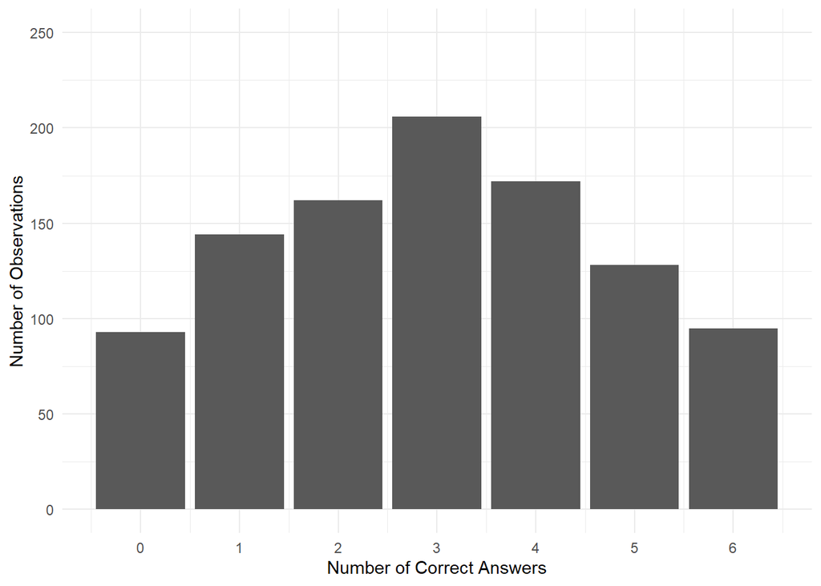

```r
pol_knowledge_plot <- data_long[data_long$policy_issue == 1, ] %>%
  count(knowledge) %>%
  ggplot(aes(x = knowledge, y = n)) +
  geom_bar(stat = "identity") +
  labs(x = "Number of Correct Answers",
       y = "Number of Observations") +
  scale_x_continuous(breaks = seq(min(data_long$knowledge),
                                  max(data_long$knowledge), by = 1)) +
  scale_y_continuous(limits = c(0, 250)) +
  theme_minimal()

pol_knowledge_plot
```

### Figure 2 - Distribution realism

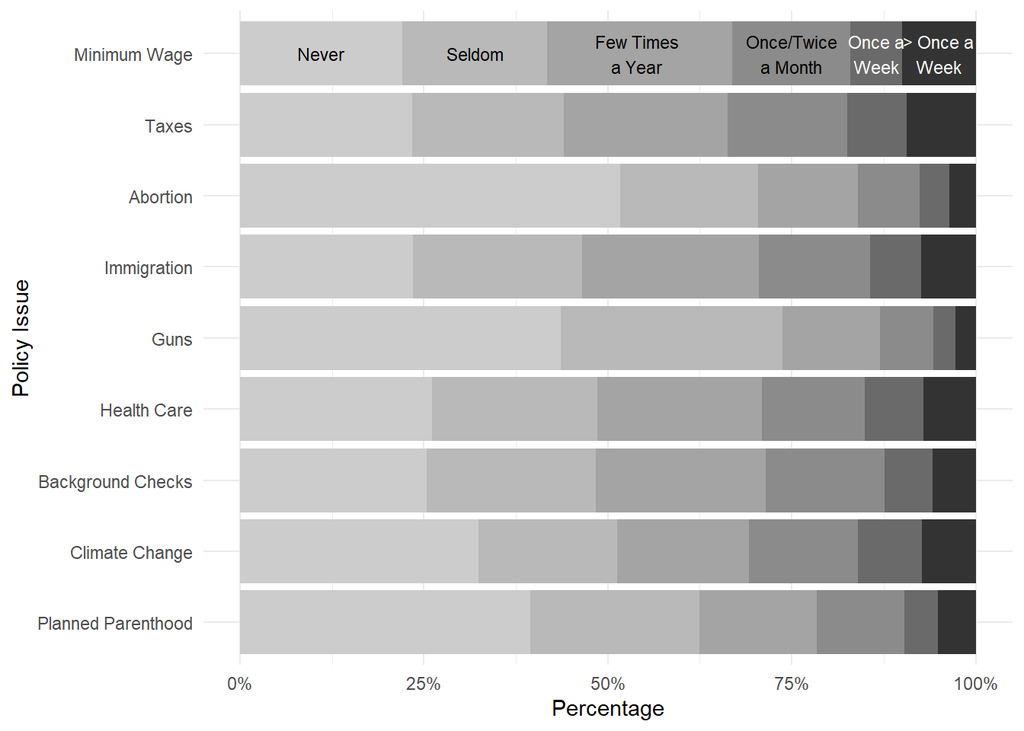

```r
discussion_counts <- data_long %>%
  pivot_longer(
    cols = starts_with("inverted_BGU_discussion"),
    names_to = "policy_variable", # This will hold the names of your discussion variables
    values_to = "discussion_level") %>%
  filter(!is.na(discussion_level)) %>%
  # We need a new variable to distinguish between different policy issues if it's not already present in the data.
  mutate(policy_issue = str_extract(policy_variable, "\\d+")) %>%
  group_by(policy_issue, discussion_level) %>%
  summarise(count = n(), .groups = 'drop') %>%
  group_by(policy_issue) %>%
  mutate(percentage = count / sum(count)) %>%
  ungroup()

# Rename the levels with the actual policy names
policy_issue_names <- c("Minimum Wage", "Taxes", "Abortion", "Immigration",
                        "Guns", "Health Care", "Background Checks", "Climate Change",
                        "Planned Parenthood")

# reorder the levels
discussion_counts$policy_issue <- factor(discussion_counts$policy_issue,
                                         levels = rev(unique(discussion_counts$policy_issue)))

levels(discussion_counts$policy_issue) <- rev(policy_issue_names)

discussion_counts$discussion_level <- factor(discussion_counts$discussion_level, levels = c(6, 5, 4, 3, 2, 1))

realism_plot <- ggplot(discussion_counts, aes(x = policy_issue, y = percentage, fill = discussion_level)) +
  geom_bar(stat = "identity", position = "fill") +
  scale_fill_grey(start = 0.2, end = 0.8) +  # Light to dark for levels 1 to 6
  labs(x = "Policy Issue", y = "Percentage", fill = "Discussion Frequency") +
  theme_minimal() +
  scale_y_continuous(labels = scales::percent_format(scale = 100)) +
  theme(legend.position = "none") +
  coord_flip() +
  annotate("text", x = "Minimum Wage", y = 0.95, label = "> Once a\nWeek", size = 3,
           hjust = 0.5, vjust = 0.5, color = "white") +
  annotate("text", x = "Minimum Wage", y = 0.865, label = "Once a\nWeek", size = 3,
           hjust = 0.5, vjust = 0.5, color = "white") +
  annotate("text", x = "Minimum Wage", y = 0.75, label = "Once/Twice\na Month", size = 3,
           hjust = 0.5, vjust = 0.5, color = "black") +
  annotate("text", x = "Minimum Wage", y = 0.54, label = "Few Times\na Year", size = 3,
           hjust = 0.5, vjust = 0.5, color = "black") +
  annotate("text", x = "Minimum Wage", y = 0.32, label = "Seldom", size = 3,
           hjust = 0.5, vjust = 0.5, color = "black") +
  annotate("text", x = "Minimum Wage", y = 0.11, label = "Never", size = 3,
           hjust = 0.5, vjust = 0.5, color = "black")

realism_plot
```